# 每週一圖作業繪圖說明檔

#### 環境設定

以下為老師執行時一定會存在的環境設定

```r
rm(list=ls())
library(dplyr); library(stringr); library(ggplot2); library(plotly); library(lubridate); library(readr); library(colorspace); library(grDevices); library(shiny); library(shinyjs); library(scales)
library(tidyr); library(showtext); library(tidyverse); library(colorspace);library(wesanderson);library(RColorBrewer);library(treemap)


#font_add("QYuan","cwTeXQYuan-Medium.ttf") # 新增字體
showtext_auto(enable=TRUE) #啟用字體
theme_set(theme_classic())
knitr::opts_chunk$set(fig.align='center', fig.showtext=T)
```

#### 繪圖程式

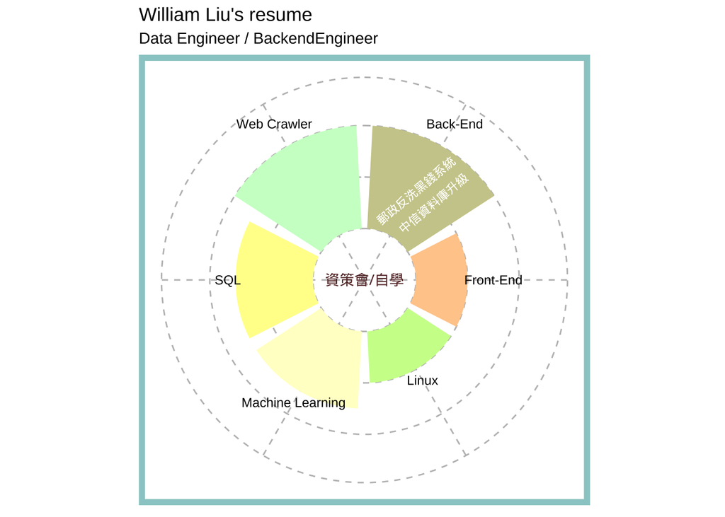

```r
# load("graphData.Rda") # 此行為第一行
load("graphData.Rda")

graphData%>%
  ggplot()+
  geom_bar(aes(x=技能,y=比例,fill=技能,label=技能),stat="identity",width = 0.9)+
  scale_fill_manual(values=c("#CCCC99","#FFCC99","#CCFF99","#FFFFCC","#FFFF99","#CCFFCC") )+geom_text(aes(x=技能,y = c(5,3,3.5,5,3.3,2.5),label=技能),size=3.2)+
    annotate("text", x = 1, y = 2,
           label = paste("郵政反洗黑錢系統"), size = 3,angle=40,colour="white")+
    annotate("text", x = 1.2, y = 2,
           label = paste("中信資料庫升級"), size = 3,angle=40,colour="white")+
    labs(title="William Liu's resume",
       subtitle = "Data Engineer / BackendEngineer")+
  theme(axis.title.x=element_blank(),
        axis.text.x=element_blank(),
        axis.ticks.x=element_blank(),
        axis.line.x=element_blank(),
        axis.line.y=element_blank(),
        axis.text.y=element_blank(),
        axis.title.y=element_blank(),
        axis.ticks.y=element_blank(),
      legend.position = "none")+
  coord_polar()  +
  theme(panel.background = element_rect(colour= "#99CCCC",size=4,linetype="solid"),
        panel.grid.major=element_line(colour='grey',linetype="dashed"))+
  annotate("text", x = 2, y = -2,
           label = paste("資策會/自學"), size = 3.6,colour="#663333")
```

#### 設計說明

說明想傳達的訊息（必要）及設計想法（非必要）。寫在***下一行。

原履歷：https://www.cakeresume.com/resumes/willy11342002

欲傳達訊息：

履歷所有者(以下稱作者)在他的履歷上展列出他在設計、軟體工程各個領域有著多樣化的經驗， 所以透過此圖能看得出作者的跨領域能力，以及其應用深淺。 因為有標明他現在是後端工程師，所以將他後端的作品標在圖上，讓讀者可以知道他於後端的作品。

設計想法：

作者並非本科出身，他是透過資策會的課程和自學而習得程式能力，所以我在其源頭標在中間， 從圓心(資策會/自學)向外發展出多方面的程式應用能力， 另外因為不想讓讀者感覺到其有相關性，所以挑選不同的顏色，但作者在後端和網路爬蟲在原履歷中提到的經驗和應用的較多，所以有按原履歷提到的比例分配面積，讓讀者可以一眼知道有跨領域能力但後端和網路爬蟲較為熟練。